# A4: Joining and Merging

## Setup

**Action:** - Download the following files from Canvas or the Box folder [link here](https://clemson.box.com/s/mh6fx9wmasiqxxeufl7kmt73lo2rjdgt)

- **enrollment.csv** [- Canvas Link here](https://clemson.instructure.com/files/23693315/download?download_frd=1)
- **prices.csv** [- Canvas Link here](https://clemson.instructure.com/files/23693317/download?download_frd=1)
- **purchases.csv** [- Canvas Link here](https://clemson.instructure.com/files/23693319/download?download_frd=1)
- **survey.csv** [- Canvas Link here](https://clemson.instructure.com/files/23693320/download?download_frd=1)
- **A4_Full_Assignment_Template.Rmd** [- Canvas Link](https://clemson.instructure.com/courses/237270/files/23693713/download?download_frd=1)

#### Do all Actions in the appropriate location of the Full Assignment Template

## Exercise 1

For this exercise you have 2 datasets: `enrollment` and `survey`

```r
> enrollment
```

| id | name |
| --- | --- |
| 1 | Dave Friday |
| 2 | Hermine |
| 3 | Sura Selvarajah |

```r
> survey
```

| id | name | username |
| --- | --- | --- |
| 2 | Hermine | bakealongwithhermine |
| 3 | Sura | surasbakes |
| 4 | Peter | peter_bakes |
| 5 | Mark | thebakingbuddha |

- **enrollment**: official university enrollment records for a class
- **survey**: Student provided info missing students who never filled it out and including students who filled it out but dropped the class

**Action:** Import the enrollment and survey files.

**Action:**

Join the `enrollment` and `survey` data so that you have a list of the students in the class with their survey responses.

Your output should look like the following…

| id | name.x | name.y | username |
| --- | --- | --- | --- |
| 1 | Dave Friday | NA | NA |
| 2 | Hermine | Hermine | bakealongwithhermine |
| 3 | Sura Selvarajah | Sura | surasbakes |

**Action:**

Use a join function to provide a list of students that did not fill out the survey.

Your output should look like the following…

| id | name |
| --- | --- |
| 1 | Dave Friday |

**Action:**

Use a join function to provide a list of students that filled out the survey but have dropped the course.

Your output should look like the following…

| id | name | username |
| --- | --- | --- |
| 4 | Peter | peter_bakes |
| 5 | Mark | thebakingbuddha |

## Exercise 2

For this Exercise you have 2 datasets `purchases` and `prices`

```r
> purchases
```

| customer_id | item |
| --- | --- |
| 1 | bread |
| 1 | milk |
| 1 | banana |
| 2 | milk |
| 2 | toilet paper |

```r
> prices
```

| item | price |
| --- | --- |
| avocado | 0.50 |
| banana | 0.15 |
| bread | 1.00 |
| milk | 0.80 |
| toilet paper | 3.00 |

- **purchases**: One row per customer per item, listing purchases they made
- **prices**: One row per item in the store, listing their prices

**Action:** Import the purchases and prices datasets

**Action:**

Join the `purchases` and `prices` datasets to obtain a list purchases with their prices.

Your output should look like the following…

| customer_id | item | price |
| --- | --- | --- |
| 1 | bread | 1.00 |
| 1 | milk | 0.80 |
| 1 | banana | 0.15 |
| 2 | milk | 0.80 |
| 2 | toilet paper | 3.00 |

**Action:** Use a join function and the `summarize` function to obtain an amount of total revenue for purchases.

Your output should look like the following…

| total_revenue |
| --- |
| 5.75 |

**Action:**

Find the total revenue per customer.

(Hint: You MAY need to use a join function, `group_by` and `summarise` functions.)

Your output should look like the following…

| customer_id | total_revenue |
| --- | --- |
| 1 | 1.95 |
| 2 | 3.80 |

## Exercise 3

**Action:** We will use the `flights` dataset from `nycflights13` package. The goal for this exercise is to use some of the skills learned in Module A4 to create a line graph for 4 different carriers of **Mean Arrival Delays** over 12 months. Your graph should look **similar** (does not have to be exact) to the following graph. You must choose 4 carriers to explore, you do not have to use the 4 chosen in this graph.

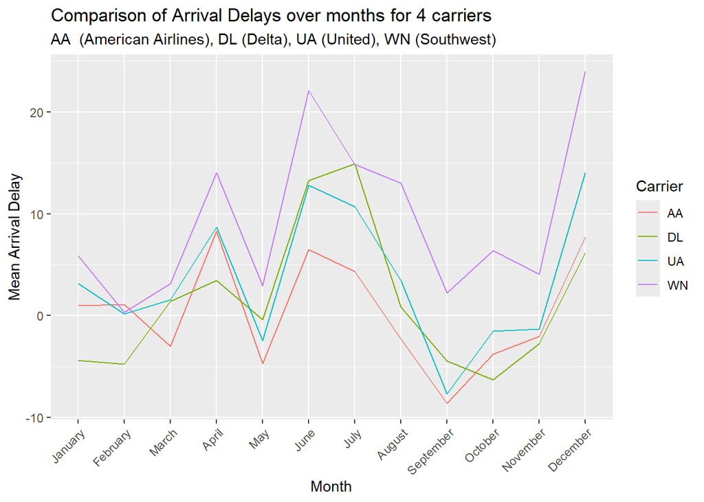

Creating this graph will likely be done in MANY steps. You may fist want to filter and transform the data before creating the graph.

You must have:

- Mean Arrival Delay as your y axis
- Months in “word” form on x axis
- Your tick marks should be titled
- You must choose 4 carriers

Helpful Hint: In order to get the x axis labels tilted, use information from this blog post [Here](https://www.r-bloggers.com/2021/09/how-to-rotate-axis-labels-in-ggplot2/)

**Action:**

Please submit your .html file to Canvas.

# References

1. R Documentation: Join - https://www.rdocumentation.org/packages/dplyr/versions/0.7.8/topics/join
2. Data Science in a Box - [Unit 2 - Deck 8: Working with multiple data frames](https://datasciencebox.org/exploring-data.html)